# IODS course project

Lauri Sillanmäki

# Introduction to Open Data Science - Course Project

# About the project

```r
date()
```

```
## [1] "Thu Nov 12 20:11:33 2020"
```

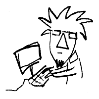

### Feelings and expectations

How am I feeling? Currently I’m a bit exhausted with all the technical challenges I had with Git and Rstudio integration with several computers. After installing brand new Linux system things were going better though.

So the course started with

- problems
- troubles
- challenges

…but from this on I’m expecting

- easiness
- joy
- wisdom.

I expect to learn R and Git integration, *and already did*. Looking forward to hear ideas for some **data analysis**: I have experience with another software and R packages as well, but with R it’s sometimes difficult to see which packages and tehchiques are used and recommended.

I heard about this course when Kimmo was advertising it via Statnet mailing list.

### R calculations…

```r
1+1
```

```
## [1] 2
```

```r
0/0
```

```
## [1] NaN
```

### …and inline code.

Square root of two equals 1.4142136.

### My GithHub repository:

https://github.com/irual/IODS-project

# Introduction to Open Data Science 2020, Week 2

## Regression analysis excercise

This week’s exercise is about regression analysis. Tasks include:

- data import and simple manipulation
- data exploration
- single and multiple predictor linear regression analysis including model diagnostics and interpretation.

Source data: http://s3.amazonaws.com/assets.datacamp.com/production/course_2218/datasets/learning2014.txt.

```r
date()
```

```
## [1] "Thu Nov 12 20:11:33 2020"
```

### Starting routines and getting to know data

```r
#Setting working path
setwd("/home/ls/R/projekteja/IODS-project/")

#Reading saved datafile as "excercise2"
exercise2_data <- read.table("./data/ex2.rData")

#Structure of data set (166 obs, 7 vars)
str(exercise2_data)
```

```
## 'data.frame':    166 obs. of  7 variables:
##  $ gender  : Factor w/ 2 levels "F","M": 1 2 1 2 2 1 2 1 2 1 ...
##  $ Age     : int  53 55 49 53 49 38 50 37 37 42 ...
##  $ Attitude: int  37 31 25 35 37 38 35 29 38 21 ...
##  $ deep    : num  3.58 2.92 3.5 3.5 3.67 ...
##  $ stra    : num  3.38 2.75 3.62 3.12 3.62 ...
##  $ surf    : num  2.58 3.17 2.25 2.25 2.83 ...
##  $ Points  : int  25 12 24 10 22 21 21 31 24 26 ...
```

```r
#First 10 observations (showing single string variable, 6 continuous variables),
head(exercise2_data,n=10)
```

```
##    gender Age Attitude     deep  stra     surf Points
## 1       F  53       37 3.583333 3.375 2.583333     25
## 2       M  55       31 2.916667 2.750 3.166667     12
## 3       F  49       25 3.500000 3.625 2.250000     24
## 4       M  53       35 3.500000 3.125 2.250000     10
## 5       M  49       37 3.666667 3.625 2.833333     22
## 6       F  38       38 4.750000 3.625 2.416667     21
## 7       M  50       35 3.833333 2.250 1.916667     21
## 8       F  37       29 3.250000 4.000 2.833333     31
## 9       M  37       38 4.333333 4.250 2.166667     24
## 10      F  42       21 4.000000 3.500 3.000000     26
```

```r
summary(exercise2_data)
```

```
##  gender       Age           Attitude          deep            stra
##  F:110   Min.   :17.00   Min.   :14.00   Min.   :1.583   Min.   :1.250
##  M: 56   1st Qu.:21.00   1st Qu.:26.00   1st Qu.:3.333   1st Qu.:2.625
##          Median :22.00   Median :32.00   Median :3.667   Median :3.188
##          Mean   :25.51   Mean   :31.43   Mean   :3.680   Mean   :3.121
##          3rd Qu.:27.00   3rd Qu.:37.00   3rd Qu.:4.083   3rd Qu.:3.625
##          Max.   :55.00   Max.   :50.00   Max.   :4.917   Max.   :5.000
##       surf           Points
##  Min.   :1.583   Min.   : 7.00
##  1st Qu.:2.417   1st Qu.:19.00
##  Median :2.833   Median :23.00
##  Mean   :2.787   Mean   :22.72
##  3rd Qu.:3.167   3rd Qu.:27.75
##  Max.   :4.333   Max.   :33.00
```

```r
#Gender proportions: females 66.3%, males 33.7%
prop.table(table(exercise2_data$gender))
```

```
##
##         F         M
## 0.6626506 0.3373494
```

So that was basic information about data set, which consist of 166 observations and single factor, six continuous variables, with 66% of subjects being female. For more information, please visit http://www.helsinki.fi/~kvehkala/JYTmooc/JYTOPKYS3-meta.txt where the original data set described.

### Visualizing pairwise distributions

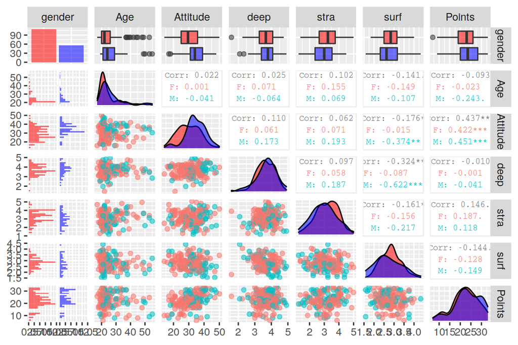

```r
#Loading additional packages and plotting bivariate distributions
library(ggplot2)
library(GGally)

ggpairs(exercise2_data, aes(col=gender, alpha=0.3),
        upper=list(continuous = wrap("cor", size=2.5)),
        lower=list(combo=wrap("facethist", bins=25))) +
  scale_fill_manual(values = c("red","blue"))
```

In graph above, red color indicates female gender, blue male. Correlation text size decreased for better fit.

Highest absolute correlation coefficient with Points are:

| Variables | Pearson R |
| --- | --- |
| Attitude * Points | 0.437 |
| stra * Points | 0.146 |
| surf * Points | -0.144 |

-> Let’s select these three as predictors. Points is the outcome.

### Multiple linear regression model #1

```r
glm1 <- lm(Points ~ Attitude + stra + surf, data=exercise2_data)
summary(glm1)
```

```
##
## Call:
## lm(formula = Points ~ Attitude + stra + surf, data = exercise2_data)
##
## Residuals:
##      Min       1Q   Median       3Q      Max
## -17.1550  -3.4346   0.5156   3.6401  10.8952
##
## Coefficients:
##             Estimate Std. Error t value Pr(>|t|)
## (Intercept) 11.01711    3.68375   2.991  0.00322 **
## Attitude     0.33952    0.05741   5.913 1.93e-08 ***
## stra         0.85313    0.54159   1.575  0.11716
## surf        -0.58607    0.80138  -0.731  0.46563
## ---
## Signif. codes:  0 '***' 0.001 '**' 0.01 '*' 0.05 '.' 0.1 ' ' 1
##
## Residual standard error: 5.296 on 162 degrees of freedom
## Multiple R-squared:  0.2074, Adjusted R-squared:  0.1927
## F-statistic: 14.13 on 3 and 162 DF,  p-value: 3.156e-08
```

Attitude is the only statistically significant predictor for Points (p<0.001).

Surf is least significant predictor: let’s remove it from the model.

### Multiple linear regression model #2

```r
glm2 <- lm(Points ~ Attitude + stra, data=exercise2_data)
summary(glm2)
```

```
##
## Call:
## lm(formula = Points ~ Attitude + stra, data = exercise2_data)
##
## Residuals:
##      Min       1Q   Median       3Q      Max
## -17.6436  -3.3113   0.5575   3.7928  10.9295
##
## Coefficients:
##             Estimate Std. Error t value Pr(>|t|)
## (Intercept)  8.97290    2.39591   3.745  0.00025 ***
## Attitude     0.34658    0.05652   6.132 6.31e-09 ***
## stra         0.91365    0.53447   1.709  0.08927 .
## ---
## Signif. codes:  0 '***' 0.001 '**' 0.01 '*' 0.05 '.' 0.1 ' ' 1
##
## Residual standard error: 5.289 on 163 degrees of freedom
## Multiple R-squared:  0.2048, Adjusted R-squared:  0.1951
## F-statistic: 20.99 on 2 and 163 DF,  p-value: 7.734e-09
```

Attitude is still the only statistically significant predictor for Points (p<0.001).

Stra is not significant, but still p<0.1. We might leave the model as it is, but out of curiosity, let’s remove Stra anyway and see what happens.

### Simple linear regression model

```r
glm3 <- lm(Points ~ Attitude, data=exercise2_data)
summary(glm3)
```

```
##
## Call:
## lm(formula = Points ~ Attitude, data = exercise2_data)
##
## Residuals:
##      Min       1Q   Median       3Q      Max
## -16.9763  -3.2119   0.4339   4.1534  10.6645
##
## Coefficients:
##             Estimate Std. Error t value Pr(>|t|)
## (Intercept) 11.63715    1.83035   6.358 1.95e-09 ***
## Attitude     0.35255    0.05674   6.214 4.12e-09 ***
## ---
## Signif. codes:  0 '***' 0.001 '**' 0.01 '*' 0.05 '.' 0.1 ' ' 1
##
## Residual standard error: 5.32 on 164 degrees of freedom
## Multiple R-squared:  0.1906, Adjusted R-squared:  0.1856
## F-statistic: 38.61 on 1 and 164 DF,  p-value: 4.119e-09
```

Model parameter estimates interpretation:

Attitude is still highly significant predictor for Points (p<0.001).

Intercept equals 11.6. This is the value of Points where Attitude=0, based on model formula.

Slope parameter of Attitude equals to 0.352, i.e. single unit increase in Attitude reflects as 0.352 increase to Points.

Coefficents of determination: unadjusted 19.1%, adjusted 18.6%. Both are a bit lower than in previous model. But let’s leave it that way.

### Diagnostic plots for model #3

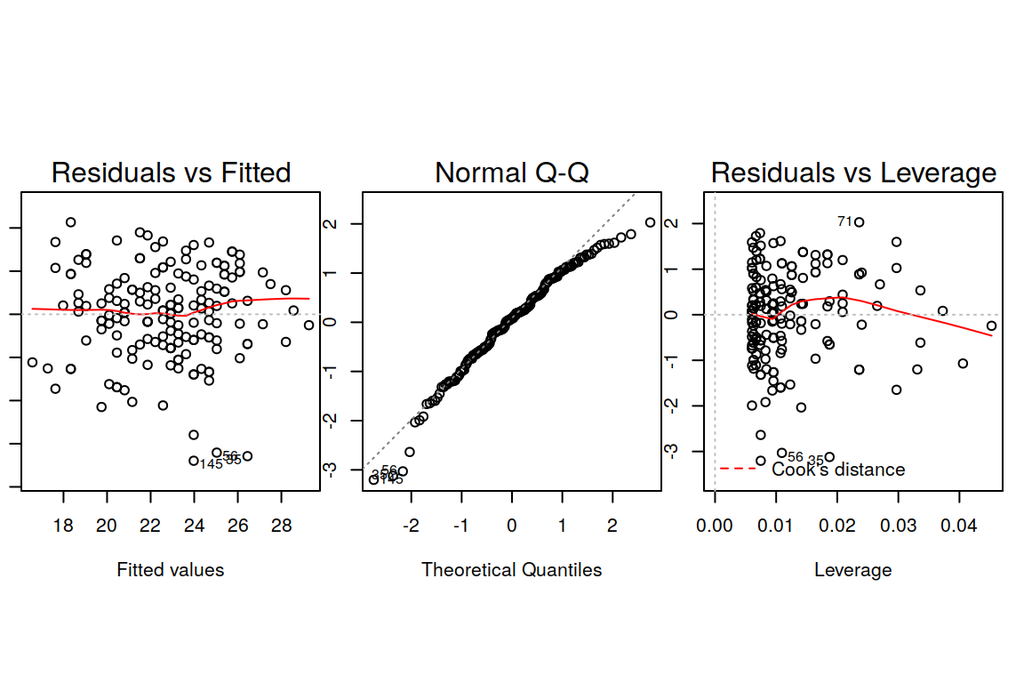

```r
#Drawing diagnostic plots. Choosing the plots 1, 2 and 5. Full list of plot options:
#1. Residual vs fitted
#2. Normal QQ plot
#3. Scale-location
#4. Cooks distance
#5. Residuals vs. Leverage
#6. Cooks distances vs Leverage

#Defining plot matrix of 1x3. Pin defines 1:1 aspect ratio for each sub plot.
par(mfrow = c(1,3), pin=c(1.75,1.75))
plot(glm3, which=c(1,2,5))
```

Normal Quantile-Quantile plot: There is slight deviation from the diagonal at the ends. However, this is still not yet alarming at all.

Residual vs. Leverage plot: Highest Cook’s distance value is <0.05, i.e. low. No problems here.

**Conclusion: model seems to be adequate, assumptions are met, based on visual examination. Attitude predicts value of Points.**

# Introduction to Open Data Science 2020, Week 3

## Logistic regression analysis excercise

This week’s exercise is about logistic regression analysis. Tasks include:

- data import and manipulation
- data exploration
- single and multiple predictor logistic regression analysis including model diagnostics and interpretation
- describing accuracy and loss
- cross validation.

```r
date()
```

```
## [1] "Thu Nov 12 20:11:44 2020"
```

Source data: Secondary school student alcohol consumption in Portugal (P. Cortez and A. Silva. Using Data Mining to Predict Secondary School Student Performance). Center for Machine Learning and Intelligent Systems at the University of California, Irvine.

Data: https://archive.ics.uci.edu/ml/datasets/Student+Performance.

Description: https://archive.ics.uci.edu/ml/datasets/Student+Performance#.

### 2. Starting routines and getting to know data

```r
#Setting working path
setwd("/home/ls/R/projekteja/IODS-project/")

#Reading the data created with "creatle_alc.R".
alc <- read.table("./data/alc.rData")
```

Loading library dplyr for further DM needs.

```r
library(dplyr)
#Variable dimensions, variable names and some values.
glimpse(alc)
```

```
## Rows: 370
## Columns: 51
## $ school     <fct> GP, GP, GP, GP, GP, GP, GP, GP, GP, GP, GP, GP, GP, GP, GP…
## $ sex        <fct> F, F, F, F, F, F, F, F, F, F, F, F, F, F, F, F, F, F, F, F…
## $ age        <int> 15, 15, 15, 15, 15, 15, 15, 15, 15, 15, 15, 15, 15, 15, 15…
## $ address    <fct> R, R, R, R, R, R, R, R, R, U, U, U, U, U, U, U, U, U, U, U…
## $ famsize    <fct> GT3, GT3, GT3, GT3, GT3, GT3, GT3, LE3, LE3, GT3, GT3, GT3…
## $ Pstatus    <fct> T, T, T, T, T, T, T, T, T, A, A, T, T, T, T, T, T, T, T, T…
## $ Medu       <int> 1, 1, 2, 2, 3, 3, 3, 2, 3, 3, 4, 1, 1, 1, 1, 1, 2, 2, 2, 3…
## $ Fedu       <int> 1, 1, 2, 4, 3, 4, 4, 2, 1, 3, 3, 1, 1, 1, 2, 2, 1, 2, 3, 2…
## $ Mjob       <fct> at_home, other, at_home, services, services, services, ser…
## $ Fjob       <fct> other, other, other, health, services, health, teacher, se…
## $ reason     <fct> home, reputation, reputation, course, reputation, course, …
## $ guardian   <fct> mother, mother, mother, mother, other, mother, father, mot…
## $ traveltime <int> 2, 1, 1, 1, 2, 1, 2, 2, 2, 1, 1, 3, 1, 1, 1, 1, 3, 1, 2, 1…
```

[output cut: 38 more lines]

So there are 370 cases and 51 variables. We’ll concentrate on  
- **alc_use**, which is derived as a mean of *Dalc* and *Walc* (workday and weekend alcohol consumption, varying from 1 - very low to 5 - very high)  
- **high_use**, which is dichotomization of *alc_use* with cut-point 2.

### 3. Selecting variables for further analysis

Choosing four interesting variables for further analysis. Response variable will be high/low alcohol consumpition.

Interesting/potential predictors I chose:  
1. *sex - student’s sex (binary: ‘F’ - female or ‘M’ - male).* Gender will definitely has an effect on alcohol consumption. On average males drink more. We’ll see how it goes here.  
2. *internet - Internet access at home (binary: yes or no).* Data is from 2014. Could be possible that subjects with internet connection are skulking at their homes instead of having a good time in restaurants etc. So internet access may decrease alcohol consumption. Maybe.  
3. *romantic - with a romantic relationship (binary: yes or no).* Having a spouse may cause a lot of stress which leads to drinking (helping or not). On the other hand, relationship may decrease drinking (all time goes sitting hand in hand or spouse may prohibit alcohol use. Who knows, there are several possible associations.  
4. *absences - number of school absences (numeric: from 0 to 93).* Drinking may cause school absences. Or there can be some common factor causing both absences and drinking. Caution: absences is count variable while other ones are dichotomous.

These predictors may have an effect, but after all it’s hard to know beforehand. Let’s explore variables and associations.

### 4. Exploring associations of alchol use and predictor. Tables and plots.

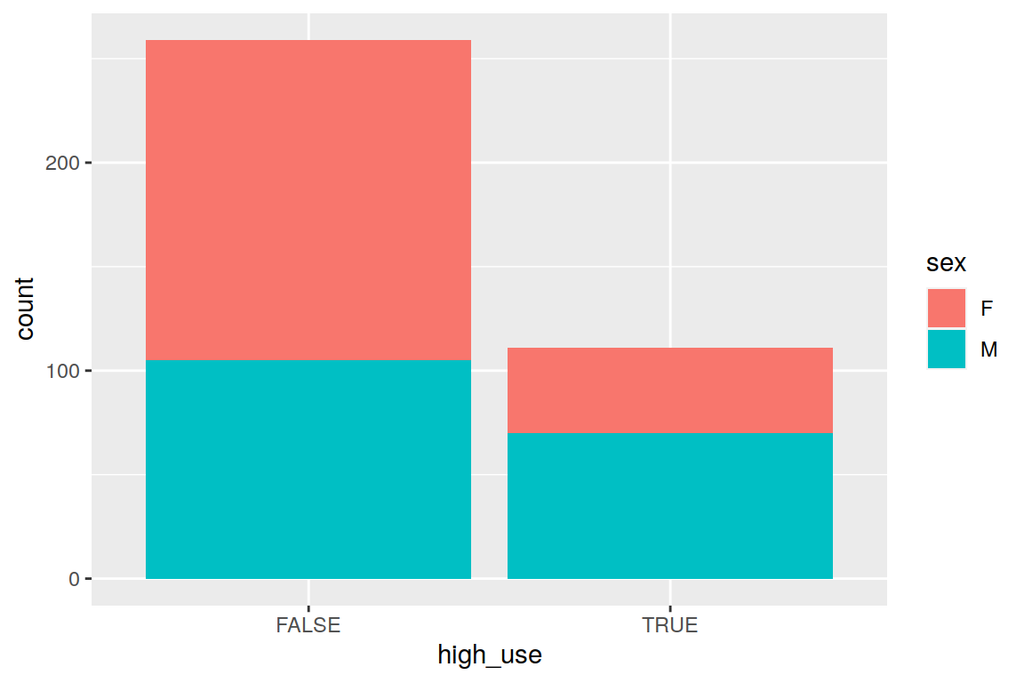

```r
#Loading ggplot2 for better plotting opportunities
library(ggplot2)

g1 <- ggplot(data = alc, aes(x = high_use))

g1 + geom_bar(aes(fill=sex))
```

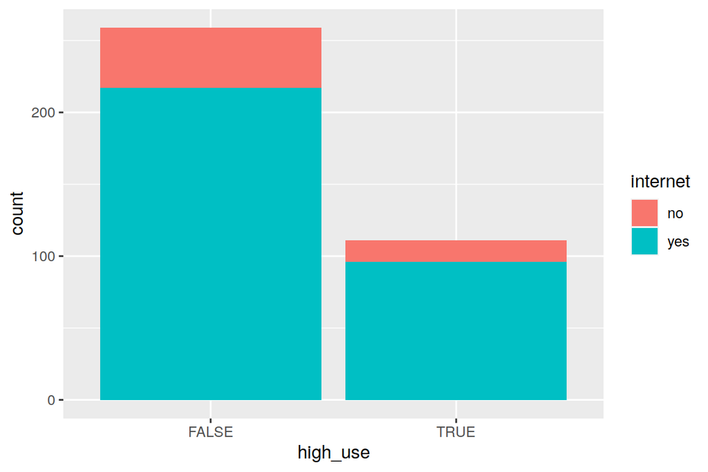

```r
g1 + geom_bar(aes(fill=internet))
```

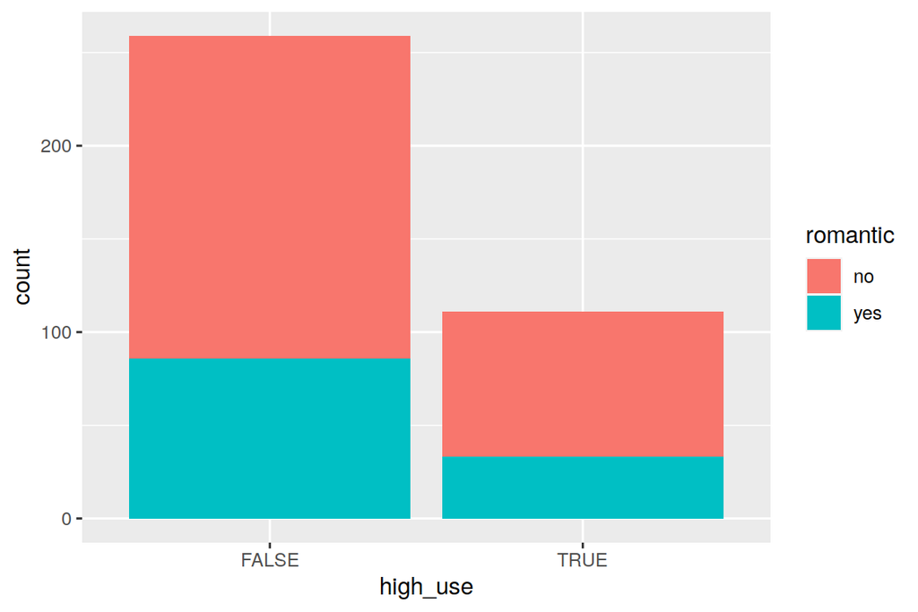

```r
g1 + geom_bar(aes(fill=romantic))
```

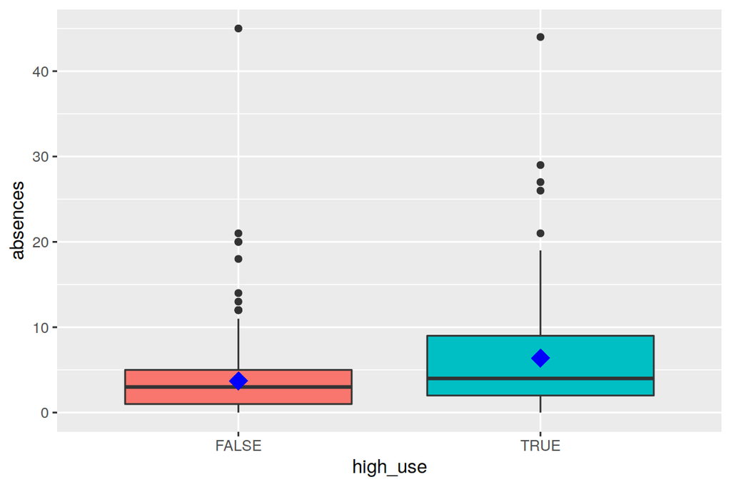

```r
g1 + geom_boxplot(aes(y=absences, fill=high_use)) +
  stat_summary(fun=mean, geom="point", aes(y=absences), col="blue", size=5, shape="diamond") +
  theme(legend.position="none")
```

One-way table and crosstabulation of alcohol use vs. predictors. Original counts.

```r
table("High alcohol use"=alc$high_use)
```

```
## High alcohol use
## FALSE  TRUE
##   259   111
```

```r
table("High alcohol use"=alc$high_use, "Sex"=alc$sex)
```

```
##                 Sex
## High alcohol use   F   M
##            FALSE 154 105
##            TRUE   41  70
```

```r
table("High alcohol use"=alc$high_use, "Internet access at home (binary: yes or no)"=alc$internet)
```

```
##                 Internet access at home (binary: yes or no)
## High alcohol use  no yes
##            FALSE  42 217
##            TRUE   15  96
```

```r
table("High alcohol use"=alc$high_use, "Romantic relationship (binary: yes or no)"=alc$romantic)
```

```
##                 Romantic relationship (binary: yes or no)
## High alcohol use  no yes
##            FALSE 173  86
##            TRUE   78  33
```

```r
#Basic descriptives by group
tapply(alc$absences, alc$high_use, summary)
```

```
## $`FALSE`
##    Min. 1st Qu.  Median    Mean 3rd Qu.    Max.
##    0.00    1.00    3.00    3.71    5.00   45.00
##
## $`TRUE`
##    Min. 1st Qu.  Median    Mean 3rd Qu.    Max.
##   0.000   2.000   4.000   6.378   9.000  44.000
```

Response counts are 259 (low) and 111 (high alcohol consumption). Crosstabs shows the same numbers as the previous plots. Abscense has higher mean in high alcohol use group (6.4 vs. 3.7).

Let’s have percentages (or proportions, to be exact) where figures are scaled for each row sum to be 100%. This can be achieved using pipe and function call prop.table(margin=1).

```r
table("High alcohol use"=alc$high_use, "Sex"=alc$sex) %>% prop.table(margin=1)
```

```
##                 Sex
## High alcohol use         F         M
##            FALSE 0.5945946 0.4054054
##            TRUE  0.3693694 0.6306306
```

```r
table("High alcohol use"=alc$high_use, "Internet access at home (binary: yes or no)"=alc$internet) %>% prop.table(margin=1)
```

```
##                 Internet access at home (binary: yes or no)
## High alcohol use        no       yes
##            FALSE 0.1621622 0.8378378
##            TRUE  0.1351351 0.8648649
```

```r
table("High alcohol use"=alc$high_use, "Romantic relationship (binary: yes or no)"=alc$romantic) %>% prop.table(margin=1)
```

```
##                 Romantic relationship (binary: yes or no)
## High alcohol use        no       yes
##            FALSE 0.6679537 0.3320463
##            TRUE  0.7027027 0.2972973
```

Proportion of males is higher in high alcohol consumption group. Gender proportions in internet access and romantic relationship groups are pretty much the same.

### 5. Logistic regression analysis

General logistic model with multiple predictors can be defined as
$$\log\left(\frac{p({\bf x})}{1 - p({\bf x})}\right) = \beta_0 + \beta_1 x_1 + \ldots + \beta_{p - 1} x_{p - 1}$$

Let’s fit binary response logistic model with multiple predictors with glm function. Outcome is high_use with TRUE indicating high alcohol consumption as an event.

```r
# find the model with glm()
# Model 1 (full model)
m1 <- glm(high_use ~ sex + internet + romantic + absences, data = alc, family = "binomial")
summary(m1)
```

```
##
## Call:
## glm(formula = high_use ~ sex + internet + romantic + absences,
##     family = "binomial", data = alc)
##
## Deviance Residuals:
##     Min       1Q   Median       3Q      Max
## -2.2366  -0.8749  -0.6095   1.1165   2.0636
##
## Coefficients:
##              Estimate Std. Error z value Pr(>|z|)
## (Intercept) -1.791835   0.354025  -5.061 4.16e-07 ***
## sexM         1.022570   0.245172   4.171 3.04e-05 ***
## internetyes  0.006198   0.340680   0.018    0.985
## romanticyes -0.217035   0.263397  -0.824    0.410
## absences     0.098186   0.023536   4.172 3.02e-05 ***
## ---
## Signif. codes:  0 '***' 0.001 '**' 0.01 '*' 0.05 '.' 0.1 ' ' 1
##
## (Dispersion parameter for binomial family taken to be 1)
##
##     Null deviance: 452.04  on 369  degrees of freedom
## Residual deviance: 414.97  on 365  degrees of freedom
## AIC: 424.97
##
## Number of Fisher Scoring iterations: 4
```

Access to internet doesn’t seem to be statistically significant predictor for high alcohol use. Let’s remove it from the model and try again.

```r
#Model 2
m2 <- glm(high_use ~ sex + romantic + absences, data = alc, family = "binomial")
summary(m2)
```

```
##
## Call:
## glm(formula = high_use ~ sex + romantic + absences, family = "binomial",
##     data = alc)
##
## Deviance Residuals:
##     Min       1Q   Median       3Q      Max
## -2.2370  -0.8745  -0.6091   1.1168   2.0641
##
## Coefficients:
##             Estimate Std. Error z value Pr(>|z|)
## (Intercept) -1.78707    0.23822  -7.502 6.30e-14 ***
## sexM         1.02291    0.24444   4.185 2.86e-05 ***
## romanticyes -0.21668    0.26268  -0.825    0.409
## absences     0.09823    0.02341   4.196 2.72e-05 ***
## ---
## Signif. codes:  0 '***' 0.001 '**' 0.01 '*' 0.05 '.' 0.1 ' ' 1
##
## (Dispersion parameter for binomial family taken to be 1)
##
##     Null deviance: 452.04  on 369  degrees of freedom
## Residual deviance: 414.97  on 366  degrees of freedom
## AIC: 422.97
##
## Number of Fisher Scoring iterations: 4
```

Couple relationship either doesn’t seem to be statistically significant predictor for high alcohol. Let’s remove it from the model as well and try again.

```r
#Model 3 (final model)
m3 <- glm(high_use ~ sex + absences, data = alc, family = "binomial")
summary(m3)
```

```
##
## Call:
## glm(formula = high_use ~ sex + absences, family = "binomial",
##     data = alc)
##
## Deviance Residuals:
##     Min       1Q   Median       3Q      Max
## -2.2706  -0.8838  -0.5901   1.0960   1.9993
##
## Coefficients:
##             Estimate Std. Error z value Pr(>|z|)
## (Intercept) -1.85303    0.22609  -8.196 2.49e-16 ***
## sexM         1.03451    0.24395   4.241 2.23e-05 ***
## absences     0.09671    0.02336   4.140 3.48e-05 ***
## ---
## Signif. codes:  0 '***' 0.001 '**' 0.01 '*' 0.05 '.' 0.1 ' ' 1
##
## (Dispersion parameter for binomial family taken to be 1)
##
##     Null deviance: 452.04  on 369  degrees of freedom
## Residual deviance: 415.66  on 367  degrees of freedom
## AIC: 421.66
##
## Number of Fisher Scoring iterations: 4
```

Now both remaining factors are statistically significant (p<0.001), we can leave the model as it is. Slope parameter for Sex (being male as an event) is 1.03, with standard error 0.24, for the event of alcohol consumption being high. However, this is log-odds, which may be difficult to interpret. Therefor, let’s calculate and show Odds Ratios which are exponentiated versions of shown estimates, i.e. constant *e* is raised to power of that number.

This is somewhat plausible result. I’m still surprised that internet access and couple relationsip didn’t have any significant role.

```r
# compute odds ratios (OR)
OR <- coef(m3) %>% exp

# compute confidence intervals (CI)
CI <- confint(m3) %>% exp
# print out the odds ratios with their confidence intervals
cbind(OR, CI)
```

```
##                    OR      2.5 %    97.5 %
## (Intercept) 0.1567616 0.09877521 0.2401977
## sexM        2.8137400 1.75518106 4.5760120
## absences    1.1015380 1.05453436 1.1557571
```

So the Odds Ratio (95% Confidence Interval) for Sex is 2.81 (1.76-4.58) and for absences 1.10 (1.05-1.16). Males has 2.8-fold odds of becoming to high alcohol consumption group compared to females. Similarly, single unit increase in absence count scale makes odds of being in high alcohol consumption group grow 1.1-fold, i.e. it increases 10%.

Just to be sure, let’s fit single predictor model and compare manual OR calculation with R model results.

```r
#Model 4 (single predictor model)
m4 <- glm(high_use ~ sex, data = alc, family = "binomial")
OR <- coef(m4) %>% exp
CI <- confint(m4) %>% exp
cbind(OR, CI)
```

```
##                    OR     2.5 %    97.5 %
## (Intercept) 0.2662338 0.1863238 0.3717646
## sexM        2.5040650 1.5902950 3.9838892
```

```r
# tabulate the target variable versus the predictor
table(high_use = alc$high_use, alc$sex)
```

```
##
## high_use   F   M
##    FALSE 154 105
##    TRUE   41  70
```

OR for sex in single predictor model was 2.5040650. We are supposed to get the same result when calculating males/girls ratio in high vs. low alcohol consumption group, i.e.

$$\frac{154/105} {41/70}$$

```r
#Calculate with R
(154/105)/(41/70)
```

```
## [1] 2.504065
```

Yes, it works.

### 6. Studying predictive power of logistic regression model

Let’s see how previous model #3 is able predict alcohol usage.

Providing a 2x2 cross tabulation of predictions versus the actual values. First we need to predict values, add them into data set, categorize results and peep the data.

```r
# predict() the probability of high_use
probabilities <- predict(m3, type = "response")

# add the predicted probabilities to 'alc'
alc <- mutate(alc, probability = probabilities)

# use the probabilities to make a prediction of high_use
alc <- mutate(alc, prediction = probability > 0.5)

# see the last ten original classes, predicted probabilities, and class predictions
select(alc, sex, probability, high_use, prediction) %>% tail(15)
```

```
##     sex probability high_use prediction
## 356   M   0.3708919     TRUE      FALSE
## 357   M   0.3937240     TRUE      FALSE
## 358   M   0.3486225     TRUE      FALSE
## 359   M   0.3486225    FALSE      FALSE
## 360   M   0.5129601     TRUE       TRUE
## 361   M   0.4646683     TRUE      FALSE
## 362   M   0.3708919     TRUE      FALSE
## 363   M   0.3486225     TRUE      FALSE
## 364   M   0.3937240     TRUE      FALSE
## 365   M   0.3708919    FALSE      FALSE
## 366   M   0.3937240     TRUE      FALSE
## 367   M   0.3060791    FALSE      FALSE
## 368   M   0.3937240     TRUE      FALSE
## 369   M   0.4887880     TRUE      FALSE
## 370   M   0.3060791    FALSE      FALSE
```

Now we are ready to see how predictions matches the reality.

```r
# tabulate the target variable versus the predictions
table(high_use = alc$high_use, prediction = alc$prediction)
```

```
##         prediction
## high_use FALSE TRUE
##    FALSE   251    8
##    TRUE     86   25
```

```r
table(high_use = alc$high_use, prediction = alc$prediction) %>% prop.table(margin=1)
```

```
##         prediction
## high_use      FALSE       TRUE
##    FALSE 0.96911197 0.03088803
##    TRUE  0.77477477 0.22522523
```

In low alc. group prediction goes right in 97% cases, in high group prediction is correct only in 23% of cases. Clearly model is prone to find cases of low alcohol consumption, but has difficulties to find users of higher level of alcohol.

Let’s plot the results.

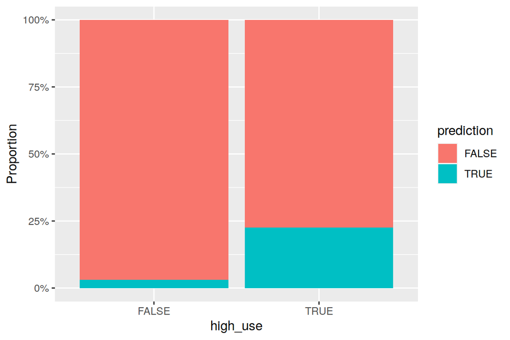

```r
# Some data management. Proportions into data frame.
props <- as.data.frame(table(high_use = alc$high_use, prediction = alc$prediction) %>% prop.table(margin=1))

# Plotting with ggplot2
ggplot(data = props) +
  geom_bar(stat="identity", aes(x=high_use, y=Freq, fill=prediction)) +
  scale_y_continuous(labels=scales::percent) +
  ylab("Proportion")
```

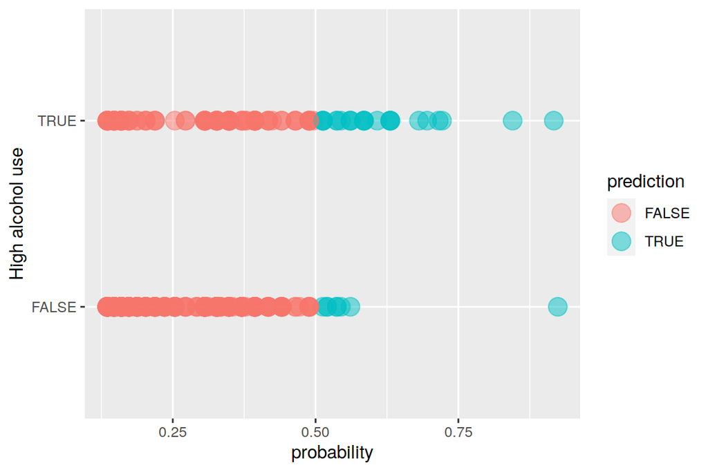

```r
# Plotting with ggplot2
ggplot(data = alc) +
  geom_point(aes(x = probability, y = high_use, color = prediction), size=5, alpha=0.5) +
  ylab("High alcohol use")
```

This shows the same story. With selected probability 50% model will catch most low users, but is not able to detect most cases in high alcohol use group. Maybe prob. threshold of 50% should be raised?

### 7. 10-fold cross-validation (“bonus task”)

Let’s perform 10-fold cross-validation on our model and see if it has better test set performance (smaller prediction error using 10-fold cross-validation) compared to the model introduced in DataCamp (which had about 0.26 error).

```r
# define a loss function (mean prediction error)
loss_func <- function(class, prob) {
  n_wrong <- abs(class - prob) > 0.5
  mean(n_wrong)
}

# compute the average number of wrong predictions in the (training) data
loss_func(class = alc$high_use, prob = alc$probability)
```

```
## [1] 0.2540541
```

```r
library(boot)
#10-fold cross-validation
cv <- cv.glm(data = alc, cost = loss_func, glmfit = m3, K = 10)

# average number of wrong predictions in the cross validation
cv$delta[1]
```

```
## [1] 0.2594595
```

So this is only slightly lower prediction error than in DataCamp excercise - the same in practise.

### 8. 10-fold cross-validation comparison (“super-bonus task”)

Let’s conduct comparison of several cross-validations with different sets of predictors. Starting with a very high number of predictors and exploring the changes in the training and testing errors as moving to models with less predictors.

I first tried to do the whole thing with R functions, letting R to generate all models, validations and error estimates automatically. However, I wasn’t clever enough to create lists of predictors for glm without additional quotes, so I was stuck. Now modelling etc. is done manually model by model, which is akward…

```r
m1  <- glm(high_use ~ school, data = alc, family = "binomial")
m2  <- glm(high_use ~ school + sex + age, data = alc, family = "binomial")
m3  <- glm(high_use ~ school + sex + age + address, data = alc, family = "binomial")
m4  <- glm(high_use ~ school + sex + age + address + famsize, data = alc, family = "binomial")
m5  <- glm(high_use ~ school + sex + age + address + famsize + Pstatus + Medu, data = alc, family = "binomial")
m6  <- glm(high_use ~ school + sex + age + address + famsize + Pstatus + Medu + Fedu, data = alc, family = "binomial")
m7  <- glm(high_use ~ school + sex + age + address + famsize + Pstatus + Medu + Fedu + Mjob, data = alc, family = "binomial")
m8  <- glm(high_use ~ school + sex + age + address + famsize + Pstatus + Medu + Fedu + Mjob + Fjob, data = alc, family = "binomial")
m9  <- glm(high_use ~ school + sex + age + address + famsize + Pstatus + Medu + Fedu + Mjob + Fjob + reason, data = alc, family = "binomial")
m10 <- glm(high_use ~ school + sex + age + address + famsize + Pstatus + Medu + Fedu + Mjob + Fjob + reason + guardian, data = alc, family = "binomial")
m11 <- glm(high_use ~ school + sex + age + address + famsize + Pstatus + Medu + Fedu + Mjob + Fjob + reason + guardian + traveltime, data = alc, family = "binomial")
m12 <- glm(high_use ~ school + sex + age + address + famsize + Pstatus + Medu + Fedu + Mjob + Fjob + reason + guardian + traveltime + studytime, data = alc, family = "binomial")
m13 <- glm(high_use ~ school + sex + age + address + famsize + Pstatus + Medu + Fedu + Mjob + Fjob + reason + guardian + traveltime + studytime + schoolsup, data = alc, family = "binomial")
m14 <- glm(high_use ~ school + sex + age + address + famsize + Pstatus + Medu + Fedu + Mjob + Fjob + reason + guardian + traveltime + studytime + schoolsup + famsup, data = alc, family = "binomial")
m15 <- glm(high_use ~ school + sex + age + address + famsize + Pstatus + Medu + Fedu + Mjob + Fjob + reason + guardian + traveltime + studytime + schoolsup + famsup + activities, data = alc, family = "binomial")
m16 <- glm(high_use ~ school + sex + age + address + famsize + Pstatus + Medu + Fedu + Mjob + Fjob + reason + guardian + traveltime + studytime + schoolsup + famsup + activities + nursery, data = alc, family = "binomial")
m17 <- glm(high_use ~ school + sex + age + address + famsize + Pstatus + Medu + Fedu + Mjob + Fjob + reason + guardian + traveltime + studytime + schoolsup + famsup + activities + nursery + higher, data = alc, family = "binomial")
m18 <- glm(high_use ~ school + sex + age + address + famsize + Pstatus + Medu + Fedu + Mjob + Fjob + reason + guardian + traveltime + studytime + schoolsup + famsup + activities + nursery + higher + internet, data = alc, family = "binomial")
m19 <- glm(high_use ~ school + sex + age + address + famsize + Pstatus + Medu + Fedu + Mjob + Fjob + reason + guardian + traveltime + studytime + schoolsup + famsup + activities + nursery + higher + internet + romantic, data = alc, family = "binomial")
m20 <- glm(high_use ~ school + sex + age + address + famsize + Pstatus + Medu + Fedu + Mjob + Fjob + reason + guardian + traveltime + studytime + schoolsup + famsup + activities + nursery + higher + internet + romantic + famrel, data = alc, family = "binomial")
```

That was the modeling. Next, let’s conduct 10-fold cross-validation for each model.

```r
cv1  <- cv.glm(data = alc, cost = loss_func, glmfit = m1,  K = 10)
cv2  <- cv.glm(data = alc, cost = loss_func, glmfit = m2,  K = 10)
cv3  <- cv.glm(data = alc, cost = loss_func, glmfit = m3,  K = 10)
cv4  <- cv.glm(data = alc, cost = loss_func, glmfit = m4,  K = 10)
cv5  <- cv.glm(data = alc, cost = loss_func, glmfit = m5,  K = 10)
cv6  <- cv.glm(data = alc, cost = loss_func, glmfit = m6,  K = 10)
cv7  <- cv.glm(data = alc, cost = loss_func, glmfit = m7,  K = 10)
cv8  <- cv.glm(data = alc, cost = loss_func, glmfit = m8,  K = 10)
cv9  <- cv.glm(data = alc, cost = loss_func, glmfit = m9,  K = 10)
cv10 <- cv.glm(data = alc, cost = loss_func, glmfit = m10, K = 10)
cv11 <- cv.glm(data = alc, cost = loss_func, glmfit = m11, K = 10)
cv12 <- cv.glm(data = alc, cost = loss_func, glmfit = m12, K = 10)
cv13 <- cv.glm(data = alc, cost = loss_func, glmfit = m13, K = 10)
cv14 <- cv.glm(data = alc, cost = loss_func, glmfit = m14, K = 10)
cv15 <- cv.glm(data = alc, cost = loss_func, glmfit = m15, K = 10)
cv16 <- cv.glm(data = alc, cost = loss_func, glmfit = m16, K = 10)
cv17 <- cv.glm(data = alc, cost = loss_func, glmfit = m17, K = 10)
cv18 <- cv.glm(data = alc, cost = loss_func, glmfit = m18, K = 10)
cv19 <- cv.glm(data = alc, cost = loss_func, glmfit = m19, K = 10)
cv20 <- cv.glm(data = alc, cost = loss_func, glmfit = m20, K = 10)
```

Let’s create a data frame comprising deltas and number of predictors.

```r
deltas <- c(cv1$delta[1],  cv2$delta[1],  cv3$delta[1],  cv4$delta[1],  cv5$delta[1],
            cv6$delta[1],  cv7$delta[1],  cv8$delta[1],  cv9$delta[1],  cv10$delta[1],
            cv11$delta[1], cv12$delta[1], cv13$delta[1], cv14$delta[1], cv15$delta[1],
            cv16$delta[1], cv17$delta[1], cv18$delta[1], cv19$delta[1], cv20$delta[1])

preds <- c(1:20)

compdata <- data.frame(deltas,preds)
```

And plotting the results.

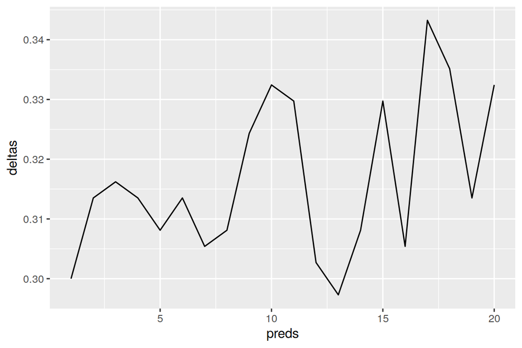

```r
ggplot(compdata, aes(x=preds, y=deltas)) +
  geom_line()
```

We’ll see that average amount of wrong predictions in the cross validation is not increasing/decreasing linearly. However, looks like error is mostly increasing when more complicated models are fitted. Simple models are more preferable.